# Ancestry PRS Load

Author

Sarah Urbut

Published

March 7, 2024

## LDL PRS analysis

```r
library(dplyr)
library(broom)
library(tidyr)
library(ggplot2)
library(data.table)
library(ggridges)
library(lubridate)
library(stringr)



prs1 = fread("./GLGC_2021_ALL_LDL_PRS_weights_PRS-CS.sortedID.sscore")

prs = fread("./test_LDL_PRScsx_customLD_comb_score")

prs=prs[,c("IID","comb_score")]
colnames(prs)=names(prs1)[c(2,5)]

#ancestry = fread("mgbb_data/GSA_53K.hg38.1KGPCA.tsv.gz")[, c(1:3)]
#s = stringr::str_split_fixed(ancestry$IID, pattern = "-", n = 2)

pheno=fread("na29.na32.5399smp_updated220923.pheno")

ldl = pheno[,c("IID","ldl1_adj")]

## we will use consent date
pheno$CAD_censor=pheno$MI

sum(na.omit(pheno$CAD_censor == 1))
```

```
[1] 3321
```

```r
sum(na.omit(pheno$CAD_censor == 0))
```

```
[1] 2009
```

```r
pheno_all_with_covs = pheno[,c("IID","Age","Sex","PC1","PC2","PC3","PC4","PC5","PC6","PC7","PC8","PC9","PC10","CAD_censor")]

totaldata=merge(pheno_all_with_covs,prs[,c("IID","SCORE1_AVG")],by="IID")
totaldata$PRS=totaldata$SCORE1_AVG
totaldata=left_join(totaldata,ldl,by = "IID")
```

# Histograms

# Using residual PRS

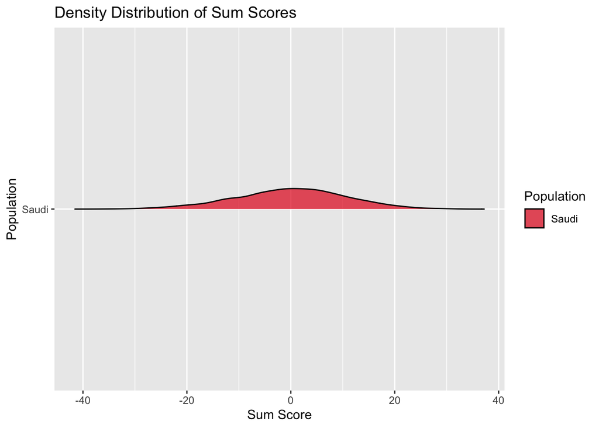

```r
library(ggridges)
pcmod = lm(PRS ~ PC1 + PC2 + PC3 + PC4 + PC5 + PC6 + PC7 + PC8 + PC9 + PC10, data = totaldata)
totaldata$predictscore = predict(object = pcmod, newdata = totaldata)
totaldata$residscore = totaldata$PRS - totaldata$predictscore
totaldata$scaled_resid = scale(totaldata$residscore)
## because only one populatino
totaldata$pop_scaled_prs = scale(totaldata$residscore)
totaldata$Population="Saudi"


ggplot(totaldata, aes(x = residscore, y = Population, fill = Population)) +
  geom_density_ridges(alpha = 0.7) +
  scale_fill_brewer(palette = "Set1") +

  labs(title = "Density Distribution of Sum Scores",
       x = "Sum Score",
       y = "Population")
```

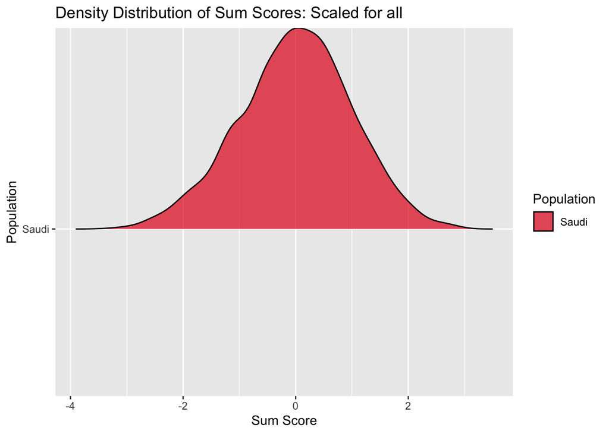

```r
ggplot(totaldata, aes(x = pop_scaled_prs, y = Population, fill = Population)) +
    geom_density_ridges(alpha = 0.7) +
    scale_fill_brewer(palette = "Set1") +
    # Optional: Adds a nice theme suitable for ridgeline plots
    labs(title = "Density Distribution of Sum Scores: Scaled for all",
         x = "Sum Score",
         y = "Population")
```

```r
library(dplyr)
totaldata%>%group_by(Population)%>%summarize(quantile(pop_scaled_prs,0.25),median(pop_scaled_prs),mean(pop_scaled_prs),quantile(pop_scaled_prs,0.75))
```

```
# A tibble: 1 × 5
  Population `quantile(pop_scaled_prs, 0.25)` `median(pop_scaled_prs)`
  <chr>                                 <dbl>                    <dbl>
1 Saudi                                -0.642                   0.0323
# ℹ 2 more variables: `mean(pop_scaled_prs)` <dbl>,
#   `quantile(pop_scaled_prs, 0.75)` <dbl>
```

# Table1

```r
library(table1)
dat <- totaldata


dat$pop_scaled_prs <- as.numeric(as.character(round(dat$pop_scaled_prs,2)))

dat <- totaldata
dat$CAD_censor <- as.factor(dat$CAD_censor)
label(dat$Sex) <- "Sex"
label(dat$ldl1_adj) <- "LDL-C (adjusted for Statin)"
label(dat$CAD_censor) <- "CAD Ever"
label(dat$scaled_resid) <- "Overall Scaled Residual PRS"
label(dat$pop_scaled_prs) <- "Pop Scaled Residual PRS"
label(dat$Age) = "Age Enrolled"

# Continue with creating the table
table1(~Sex + ldl1_adj + CAD_censor + Age + round(pop_scaled_prs,4) + scaled_resid , data = dat)
```

|  | Overall (N=2201) |
| --- | --- |
| Sex |  |
| Mean (SD) | 0.658 (0.474) |
| Median [Min, Max] | 1.00 [0, 1.00] |
| LDL-C (adjusted for Statin) |  |
| Mean (SD) | 135 (52.6) |
| Median [Min, Max] | 127 [19.3, 685] |
| CAD Ever |  |
| 0 | 795 (36.1%) |
| 1 | 1390 (63.2%) |
| Missing | 16 (0.7%) |
| Age Enrolled |  |
| Mean (SD) | 55.5 (14.0) |
| Median [Min, Max] | 56.0 [13.0, 99.0] |
| Pop Scaled Residual PRS |  |
| Mean (SD) | 0.000000318 (1.00) |
| Median [Min, Max] | 0.0323 [-3.33, 2.92] |
| Overall Scaled Residual PRS |  |
| Mean (SD) | -0.00000000000000000202 (1.00) |
| Median [Min, Max] | 0.0323 [-3.33, 2.92] |

```r
saveRDS(dat,".datfortable1_saudi.rds")
```

# Impact of PRS

To assess the impact of LDL-C PRS on CAD risk, you need to establish a two-step relationship: first, between LDL-C PRS and LDL-C levels (per 40 mg/dL change), and then between LDL-C PRS and CAD outcomes. The approach allows you to understand how changes in LDL-C levels attributed to genetic risk (as quantified by PRS) relate to CAD risk.

### **Step 1: Associate LDL-C PRS with LDL-C Levels (per 40 mg/dL)**

1. **Linear Regression for LDL-C Levels**: Fit a linear regression model with LDL-C levels as the outcome and LDL-C PRS as the predictor. You might want to adjust for relevant covariates.
2. **Rescale the Coefficient for LDL-C PRS**: Adjust the coefficient from tAMR model to reflect a 40 mg/dL change in LDL-C.

### **Step 2: Associate Rescaled LDL-C PRS with CAD**

```r
library(dplyr)
library(survival)
# Assuming 'df' is your dataset

# List of unique populations
pop="Saudi"

# Initialize an empty list for storing models and results
cox_models <- list()
glm_models = list()


results <- data.frame(
  Population = character(),
  PRS_Mean = numeric(),
  PRS_SD = numeric(),
  Percent_male = numeric(),
  LDL_Coef_CI_Lower = numeric(),
  LDL_Coef_CI_Upper = numeric(),
  Population_Scale_Factor = numeric(),
  LDL_Scaled_Coef_CI_Lower = numeric(),
  LDL_Scaled_Coef_CI_Upper = numeric(),
  HR = numeric(),
  HR_CI_Lower = numeric(),
  HR_CI_Upper = numeric(),
  OR = numeric(),
  OR_LCI = numeric(),
  OR_UCI = numeric(),
  stringsAsFactors = FALSE
)

  pop_data=totaldata
  pop_data$PRS = pop_data$pop_scaled_prs
  ##print("PRS Summary")
  #print(summary(pop_data$PRS))


  ldl_model <-
    lm(
      ldl1_adj ~ PRS + as.numeric(Age) + as.factor(Sex) + PC1 + PC2 + PC3 + PC4 + PC5 + PC6 + PC7 + PC8 + PC9 + PC10,
      data = pop_data[!is.na(pop_data$ldl1_adj),]
    )

  ldl_coef_ci <- confint(ldl_model, "PRS")
  #print(paste("LDL_coef_CI for population:", pop))
  if ("PRS" %in% names(coef(ldl_model))) {
    #print(confint(ldl_model, parm = "PRS"))
  } else {
    #print("PRS coefficient is not available in the model.")
  }
```

```r
  # Calculate the PRS scaling factor
  prs_scale_factor <- 40 / coef(ldl_model)["PRS"]
  #print(paste0(pop,":",prs_scale_factor))
  #prs_scale_factor=1
  # Scale the LDL-C PRS so that now the scaled translates to an increase of 40 mgDL
  pop_data$scaled_ldl_prs <- pop_data$PRS / prs_scale_factor


  ldl_model_2 <-
    lm(
      ldl1_adj ~ scaled_ldl_prs + Age + Sex + PC1 + PC2 + PC3 + PC4 + PC5 + PC6 + PC7 + PC8 + PC9 + PC10,
      data = pop_data[!is.na(pop_data$ldl1_adj),]
    )

  ldl_scaled_coef_ci <- confint(ldl_model_2, "scaled_ldl_prs")





  glm_model <- glm(
    CAD_censor ~ scaled_ldl_prs + Age+Sex + PC1 +
      PC2 + PC3 + PC4 + PC5 + PC6 + PC7 + PC8 + PC9 + PC10,
    data = pop_data,
    family = "binomial"
  )
  glm_models[[pop]] <- glm_model
  glm_models[[pop]] <- glm_model
  log_or = summary(glm_model)$coefficients["scaled_ldl_prs", "Estimate"]
  log_or_se = summary(glm_model)$coefficients["scaled_ldl_prs", "Std. Error"]
  or = round(exp(log_or), 2)
  lci = round(exp(log_or - 1.96 * log_or_se), 2)
  uci = round(exp(log_or + 1.96 * log_or_se), 2)

  glmci = confint(glm_model)
  glm_summary <- summary(glm_model)

  # Compile results into the data frame
  # Append to results
  results <-
    data.frame(
      Population = pop,
      PRS_Mean = mean(pop_data$PRS),
      PRS_SD = sd(pop_data$PRS),
      Percent_male = mean(pop_data$Sex == 1),


      LDL_Coef_CI_Lower = ldl_coef_ci[1],
      LDL_Coef_CI_Upper = ldl_coef_ci[2],
      Population_Scale_Factor = prs_scale_factor,
      LDL_Scaled_Coef_CI_Lower = ldl_scaled_coef_ci[1],
      # Adjust according to your calculations
      LDL_Scaled_Coef_CI_Upper = ldl_scaled_coef_ci[2],
      OR = or,
      OR_LCI = exp(glmci['scaled_ldl_prs', 1]),
      OR_UCI = exp(glmci['scaled_ldl_prs', 2])
    )




results
```

```
    Population     PRS_Mean PRS_SD Percent_male LDL_Coef_CI_Lower
PRS      Saudi -2.01767e-18      1    0.6583371          7.313235
    LDL_Coef_CI_Upper Population_Scale_Factor LDL_Scaled_Coef_CI_Lower
PRS          11.63125                4.222865                  30.8828
    LDL_Scaled_Coef_CI_Upper   OR   OR_LCI   OR_UCI
PRS                  49.1172 2.02 1.335799 3.074993
```

```r
saveRDS(results, "results_saudi_combined.rds")

#saveRDS(results, "results_saudi.rds")
```